# HR model

```python
 import pandas as pd
```

```python
df=pd.read_csv(r'C:\Users\Pratim\HR_DATASET.csv')
```

```python
df.head()
```

|  | Age | Attrition | BusinessTravel | DailyRate | Department | DistanceFromHome | Education | EducationField | EmployeeCount | EmployeeNumber | ... | RelationshipSatisfaction | StandardHours | StockOptionLevel | TotalWorkingYears | TrainingTimesLastYear | WorkLifeBalance | YearsAtCompany | YearsInCurrentRole | YearsSinceLastPromotion | YearsWithCurrManager |
| --- | --- | --- | --- | --- | --- | --- | --- | --- | --- | --- | --- | --- | --- | --- | --- | --- | --- | --- | --- | --- | --- |
| 0 | 41 | Yes | Travel_Rarely | 1102 | Sales | 1 | 2 | Life Sciences | 1 | 1 | ... | 1 | 80 | 0 | 8 | 0 | 1 | 6 | 4 | 0 | 5 |
| 1 | 49 | No | Travel_Frequently | 279 | Research & Development | 8 | 1 | Life Sciences | 1 | 2 | ... | 4 | 80 | 1 | 10 | 3 | 3 | 10 | 7 | 1 | 7 |
| 2 | 37 | Yes | Travel_Rarely | 1373 | Research & Development | 2 | 2 | Other | 1 | 4 | ... | 2 | 80 | 0 | 7 | 3 | 3 | 0 | 0 | 0 | 0 |
| 3 | 33 | No | Travel_Frequently | 1392 | Research & Development | 3 | 4 | Life Sciences | 1 | 5 | ... | 3 | 80 | 0 | 8 | 3 | 3 | 8 | 7 | 3 | 0 |
| 4 | 27 | No | Travel_Rarely | 591 | Research & Development | 2 | 1 | Medical | 1 | 7 | ... | 4 | 80 | 1 | 6 | 3 | 3 | 2 | 2 | 2 | 2 |

5 rows × 35 columns

```python
df.describe()
```

|  | Age | DailyRate | DistanceFromHome | Education | EmployeeCount | EmployeeNumber | EnvironmentSatisfaction | HourlyRate | JobInvolvement | JobLevel | ... | RelationshipSatisfaction | StandardHours | StockOptionLevel | TotalWorkingYears | TrainingTimesLastYear | WorkLifeBalance | YearsAtCompany | YearsInCurrentRole | YearsSinceLastPromotion | YearsWithCurrManager |
| --- | --- | --- | --- | --- | --- | --- | --- | --- | --- | --- | --- | --- | --- | --- | --- | --- | --- | --- | --- | --- | --- |
| count | 917.000000 | 917.000000 | 917.000000 | 917.000000 | 917.0 | 917.000000 | 917.000000 | 917.000000 | 917.000000 | 917.000000 | ... | 917.000000 | 917.0 | 917.000000 | 917.000000 | 917.000000 | 917.000000 | 917.000000 | 917.000000 | 917.000000 | 917.000000 |
| mean | 36.938931 | 785.711014 | 9.294438 | 2.921483 | 1.0 | 1413.466739 | 2.738277 | 66.231189 | 2.721919 | 2.044711 | ... | 2.637950 | 80.0 | 0.821156 | 11.179935 | 2.791712 | 2.760087 | 6.972737 | 4.217012 | 2.147219 | 4.062159 |
| std | 8.984981 | 401.902148 | 8.092566 | 1.020717 | 0.0 | 388.606884 | 1.103382 | 20.237536 | 0.720936 | 1.100400 | ... | 1.078673 | 0.0 | 0.864555 | 7.802790 | 1.292917 | 0.708047 | 5.951250 | 3.588223 | 3.176250 | 3.571395 |
| min | 18.000000 | 102.000000 | 1.000000 | 1.000000 | 1.0 | 1.000000 | 1.000000 | 30.000000 | 1.000000 | 1.000000 | ... | 1.000000 | 80.0 | 0.000000 | 0.000000 | 0.000000 | 1.000000 | 0.000000 | 0.000000 | 0.000000 | 0.000000 |
| 25% | 30.000000 | 444.000000 | 2.000000 | 2.000000 | 1.0 | 1084.000000 | 2.000000 | 49.000000 | 2.000000 | 1.000000 | ... | 2.000000 | 80.0 | 0.000000 | 6.000000 | 2.000000 | 2.000000 | 3.000000 | 2.000000 | 0.000000 | 2.000000 |
| 50% | 36.000000 | 772.000000 | 7.000000 | 3.000000 | 1.0 | 1425.000000 | 3.000000 | 66.000000 | 3.000000 | 2.000000 | ... | 3.000000 | 80.0 | 1.000000 | 10.000000 | 3.000000 | 3.000000 | 5.000000 | 3.000000 | 1.000000 | 3.000000 |
| 75% | 43.000000 | 1141.000000 | 14.000000 | 4.000000 | 1.0 | 1737.000000 | 4.000000 | 84.000000 | 3.000000 | 3.000000 | ... | 4.000000 | 80.0 | 1.000000 | 15.000000 | 3.000000 | 3.000000 | 9.000000 | 7.000000 | 3.000000 | 7.000000 |
| max | 60.000000 | 1498.000000 | 29.000000 | 5.000000 | 1.0 | 2068.000000 | 4.000000 | 100.000000 | 4.000000 | 5.000000 | ... | 4.000000 | 80.0 | 3.000000 | 40.000000 | 6.000000 | 4.000000 | 36.000000 | 17.000000 | 15.000000 | 17.000000 |

8 rows × 26 columns

```python
missing_values = df.isnull().sum()

print("Missing Values:")
print(missing_values)
```

```
Missing Values:
Age                         0
Attrition                   0
BusinessTravel              0
DailyRate                   0
Department                  0
DistanceFromHome            0
Education                   0
EducationField              0
EmployeeCount               0
EmployeeNumber              0
EnvironmentSatisfaction     0
Gender                      0
HourlyRate                  0
JobInvolvement              0
JobLevel                    0
JobRole                     0
JobSatisfaction             0
MaritalStatus               0
MonthlyIncome               0
MonthlyRate                 0
NumCompaniesWorked          0
Over18                      0
OverTime                    0
PercentSalaryHike           0
PerformanceRating           0
RelationshipSatisfaction    0
StandardHours               0
StockOptionLevel            0
TotalWorkingYears           0
TrainingTimesLastYear       0
WorkLifeBalance             0
YearsAtCompany              0
YearsInCurrentRole          0
YearsSinceLastPromotion     0
YearsWithCurrManager        0
dtype: int64
```

```python
print("Current Data Types:")
print(df.dtypes)

# Converting categorical variables to the appropriate data type (e.g., 'category')
categorical_columns = ['Education', 'EnvironmentSatisfaction', 'JobInvolvement', 'JobSatisfaction',
                        'PerformanceRating', 'RelationshipSatisfaction', 'WorkLifeBalance']

df[categorical_columns] = df[categorical_columns].astype('category')

print("\nUpdated Data Types:")
print(df.dtypes)
```

```
Current Data Types:
Age                          int64
Attrition                   object
BusinessTravel              object
DailyRate                    int64
Department                  object
DistanceFromHome             int64
Education                    int64
EducationField              object
EmployeeCount                int64
EmployeeNumber               int64
EnvironmentSatisfaction      int64
Gender                      object
HourlyRate                   int64
JobInvolvement               int64
JobLevel                     int64
JobRole                     object
JobSatisfaction              int64
MaritalStatus               object
MonthlyIncome                int64
MonthlyRate                  int64
NumCompaniesWorked           int64
Over18                      object
OverTime                    object
PercentSalaryHike            int64
PerformanceRating            int64
RelationshipSatisfaction     int64
StandardHours                int64
StockOptionLevel             int64
TotalWorkingYears            int64
TrainingTimesLastYear        int64
WorkLifeBalance              int64
YearsAtCompany               int64
YearsInCurrentRole           int64
YearsSinceLastPromotion      int64
YearsWithCurrManager         int64
dtype: object

Updated Data Types:
Age                            int64
```

[output cut: 20 more lines]

```
Over18                        object
OverTime                      object
PercentSalaryHike              int64
PerformanceRating           category
RelationshipSatisfaction    category
StandardHours                  int64
StockOptionLevel               int64
TotalWorkingYears              int64
TrainingTimesLastYear          int64
WorkLifeBalance             category
YearsAtCompany                 int64
YearsInCurrentRole             int64
YearsSinceLastPromotion        int64
YearsWithCurrManager           int64
dtype: object
```

### Visualizing Categorical Attributes

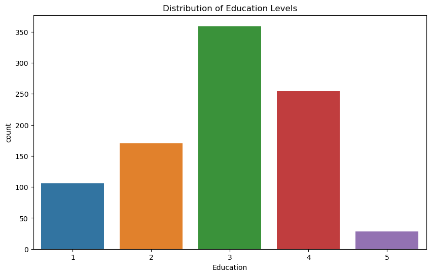

```python
import matplotlib.pyplot as plt
import seaborn as sns

plt.figure(figsize=(10, 6))
sns.countplot(x='Education', data=df)
plt.title('Distribution of Education Levels')
plt.show()
```

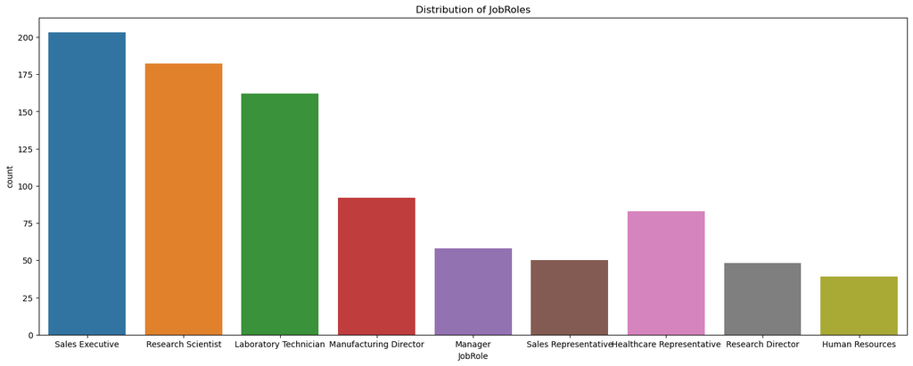

```python
plt.figure(figsize=(19, 7))
sns.countplot(x='JobRole', data=df)
plt.title('Distribution of JobRoles')
plt.show()
```

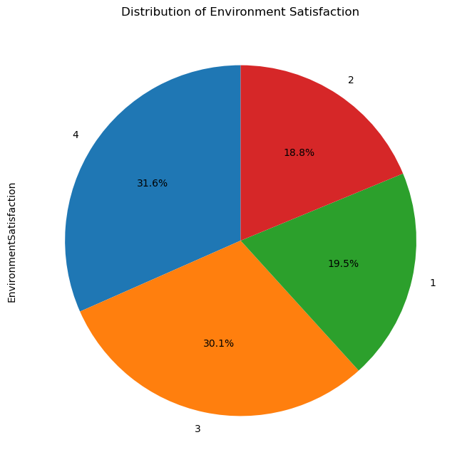

```python
 plt.figure(figsize=(8, 8))
df['EnvironmentSatisfaction'].value_counts().plot.pie(autopct='%1.1f%%', startangle=90)
plt.title('Distribution of Environment Satisfaction')
plt.show()
```

### Visualizing Numerical Attributes:

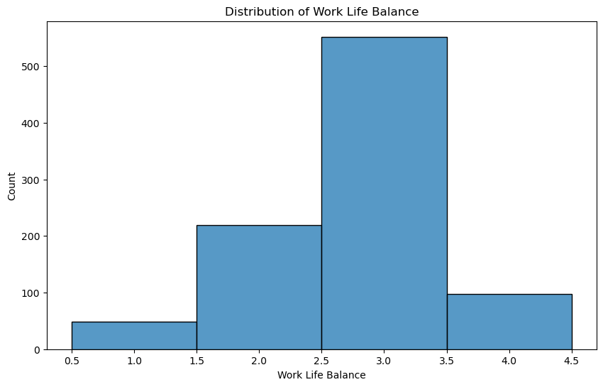

```python
plt.figure(figsize=(10, 6))
sns.histplot(df['WorkLifeBalance'], bins=4, kde=False)
plt.title('Distribution of Work Life Balance')
plt.xlabel('Work Life Balance')
plt.ylabel('Count')
plt.show()
```

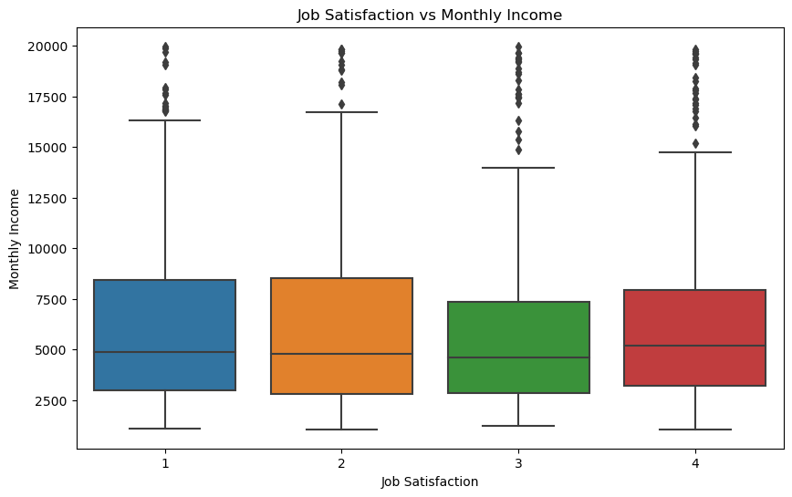

```python
plt.figure(figsize=(10, 6))
sns.boxplot(x='JobSatisfaction', y='MonthlyIncome', data=df)
plt.title('Job Satisfaction vs Monthly Income')
plt.xlabel('Job Satisfaction')
plt.ylabel('Monthly Income')
plt.show()
```

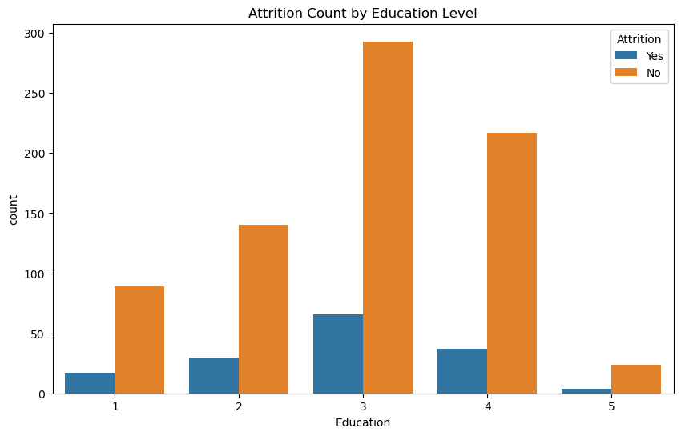

```python
plt.figure(figsize=(10, 6))
sns.countplot(x='Education', hue='Attrition', data=df)
plt.title('Attrition Count by Education Level')
plt.show()
```

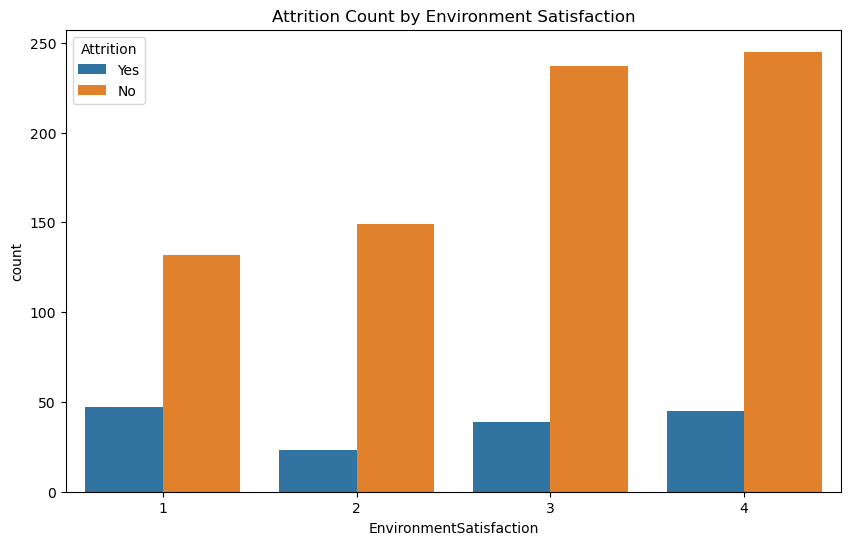

```python
plt.figure(figsize=(10, 6))
sns.countplot(x='EnvironmentSatisfaction', hue='Attrition', data=df)
plt.title('Attrition Count by Environment Satisfaction')
plt.show()
```

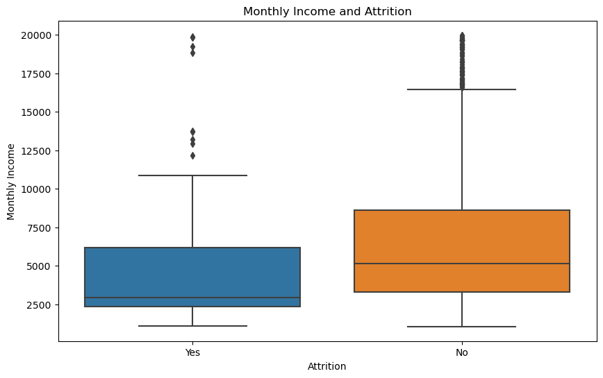

```python
plt.figure(figsize=(10, 6))
sns.boxplot(x='Attrition', y='MonthlyIncome', data=df)
plt.title('Monthly Income and Attrition')
plt.xlabel('Attrition')
plt.ylabel('Monthly Income')
plt.show()
```

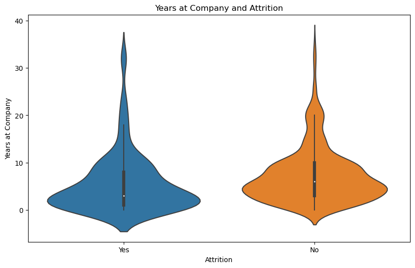

```python
plt.figure(figsize=(10, 6))
sns.violinplot(x='Attrition', y='YearsAtCompany', data=df)
plt.title('Years at Company and Attrition')
plt.xlabel('Attrition')
plt.ylabel('Years at Company')
plt.show()
```

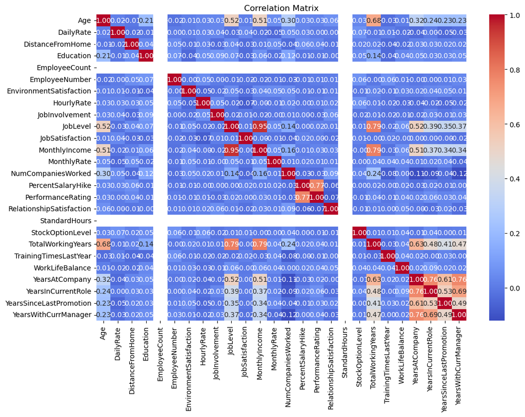

```python
# Calculate the correlation matrix
correlation_matrix = df.corr()

# Plot the heatmap
plt.figure(figsize=(12, 8))
sns.heatmap(correlation_matrix, annot=True, cmap='coolwarm', fmt='.2f')
plt.title('Correlation Matrix')
plt.show()
```

```python
# List of categorical columns to be one-hot encoded
categorical_columns = ['Education', 'EnvironmentSatisfaction', 'JobInvolvement',
                        'JobSatisfaction', 'PerformanceRating',
                        'RelationshipSatisfaction', 'WorkLifeBalance']

df_encoded = pd.get_dummies(df, columns=categorical_columns)
print(df_encoded.head())
```

```
   Age Attrition     BusinessTravel  DailyRate              Department  \
0   41       Yes      Travel_Rarely       1102                   Sales
1   49        No  Travel_Frequently        279  Research & Development
2   37       Yes      Travel_Rarely       1373  Research & Development
3   33        No  Travel_Frequently       1392  Research & Development
4   27        No      Travel_Rarely        591  Research & Development

   DistanceFromHome EducationField  EmployeeCount  EmployeeNumber  Gender  \
0                 1  Life Sciences              1               1  Female
1                 8  Life Sciences              1               2    Male
2                 2          Other              1               4    Male
3                 3  Life Sciences              1               5  Female
4                 2        Medical              1               7    Male

   ...  PerformanceRating_3  PerformanceRating_4 RelationshipSatisfaction_1  \
```

[output cut: 28 more lines]

```python
df.head()
```

|  | Age | Attrition | BusinessTravel | DailyRate | Department | DistanceFromHome | Education | EducationField | EmployeeCount | EmployeeNumber | ... | RelationshipSatisfaction | StandardHours | StockOptionLevel | TotalWorkingYears | TrainingTimesLastYear | WorkLifeBalance | YearsAtCompany | YearsInCurrentRole | YearsSinceLastPromotion | YearsWithCurrManager |
| --- | --- | --- | --- | --- | --- | --- | --- | --- | --- | --- | --- | --- | --- | --- | --- | --- | --- | --- | --- | --- | --- |
| 0 | 41 | Yes | Travel_Rarely | 1102 | Sales | 1 | 2 | Life Sciences | 1 | 1 | ... | 1 | 80 | 0 | 8 | 0 | 1 | 6 | 4 | 0 | 5 |
| 1 | 49 | No | Travel_Frequently | 279 | Research & Development | 8 | 1 | Life Sciences | 1 | 2 | ... | 4 | 80 | 1 | 10 | 3 | 3 | 10 | 7 | 1 | 7 |
| 2 | 37 | Yes | Travel_Rarely | 1373 | Research & Development | 2 | 2 | Other | 1 | 4 | ... | 2 | 80 | 0 | 7 | 3 | 3 | 0 | 0 | 0 | 0 |
| 3 | 33 | No | Travel_Frequently | 1392 | Research & Development | 3 | 4 | Life Sciences | 1 | 5 | ... | 3 | 80 | 0 | 8 | 3 | 3 | 8 | 7 | 3 | 0 |
| 4 | 27 | No | Travel_Rarely | 591 | Research & Development | 2 | 1 | Medical | 1 | 7 | ... | 4 | 80 | 1 | 6 | 3 | 3 | 2 | 2 | 2 | 2 |

5 rows × 35 columns

```python
# Calculate the overall attrition rate
attrition_rate = df['Attrition'].value_counts(normalize=True)['Yes']

print(f"Overall Attrition Rate: {attrition_rate:.2%}")
```

```
Overall Attrition Rate: 16.79%
```

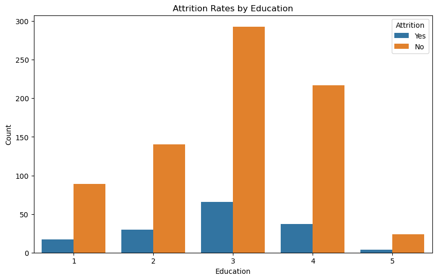

```
Attrition Rates by Education:
Attrition        No       Yes
Education
1          0.839623  0.160377
2          0.823529  0.176471
3          0.816156  0.183844
4          0.854331  0.145669
5          0.857143  0.142857
```

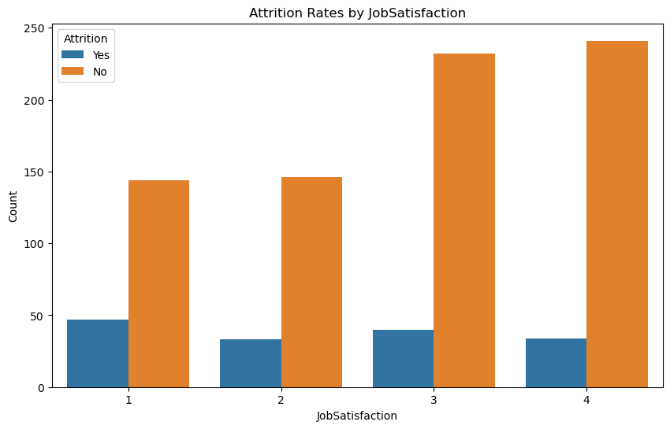

```
Attrition Rates by JobSatisfaction:
Attrition              No       Yes
JobSatisfaction
1                0.753927  0.246073
2                0.815642  0.184358
3                0.852941  0.147059
4                0.876364  0.123636
```

```python
categorical_variables = ['Education', 'JobSatisfaction']

for cat_var in categorical_variables:
    plt.figure(figsize=(10, 6))
    sns.countplot(x=cat_var, hue='Attrition', data=df)
    plt.title(f'Attrition Rates by {cat_var}')
    plt.xlabel(cat_var)
    plt.ylabel('Count')
    plt.show()

    # Calculate attrition rates for each category
    attrition_rates = df.groupby(cat_var)['Attrition'].value_counts(normalize=True).unstack().fillna(0)
    print(f"\nAttrition Rates by {cat_var}:\n{attrition_rates}\n")
```

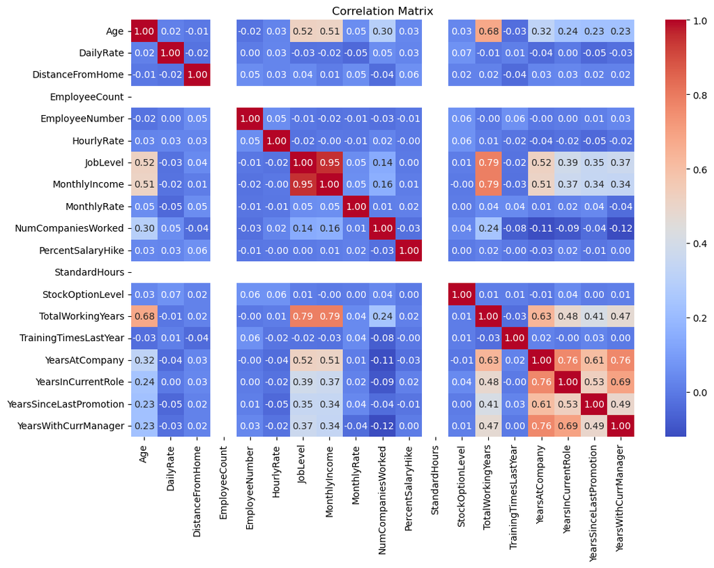

```python
numeric_columns = df.select_dtypes(include='number').columns
correlation_matrix = df[numeric_columns].corr()

# Plot the heatmap
plt.figure(figsize=(12, 8))
sns.heatmap(correlation_matrix, annot=True, cmap='coolwarm', fmt='.2f')
plt.title('Correlation Matrix')
plt.show()
```

```python
from sklearn.model_selection import train_test_split
from sklearn.linear_model import LogisticRegression
from sklearn.metrics import classification_report, accuracy_score, confusion_matrix
from sklearn.preprocessing import StandardScaler


# Select relevant features (attributes) for prediction
features = ['Education', 'EnvironmentSatisfaction', 'JobInvolvement',
            'JobSatisfaction', 'PerformanceRating',
            'RelationshipSatisfaction', 'WorkLifeBalance']

# Extract features and target variable
X = df[features]
y = df['Attrition']

# Perform one-hot encoding for categorical variables
X = pd.get_dummies(X, drop_first=True)

# Split the data into training and testing sets
X_train, X_test, y_train, y_test = train_test_split(X, y, test_size=0.2, random_state=42)

# Standardize the features (optional but can be beneficial for some models)
scaler = StandardScaler()
X_train = scaler.fit_transform(X_train)
X_test = scaler.transform(X_test)

# Initialize and train a logistic regression model
model = LogisticRegression(random_state=42)
model.fit(X_train, y_train)

# Make predictions on the test set
y_pred = model.predict(X_test)

# Evaluate the model
accuracy = accuracy_score(y_test, y_pred)
conf_matrix = confusion_matrix(y_test, y_pred)
classification_rep = classification_report(y_test, y_pred)

# Display evaluation metrics
print(f"Accuracy: {accuracy:.2f}")
print(f"\nConfusion Matrix:\n{conf_matrix}")
print(f"\nClassification Report:\n{classification_rep}")
```

```
Accuracy: 0.82

Confusion Matrix:
[[151   1]
 [ 32   0]]

Classification Report:
              precision    recall  f1-score   support

          No       0.83      0.99      0.90       152
         Yes       0.00      0.00      0.00        32

    accuracy                           0.82       184
   macro avg       0.41      0.50      0.45       184
weighted avg       0.68      0.82      0.74       184
```

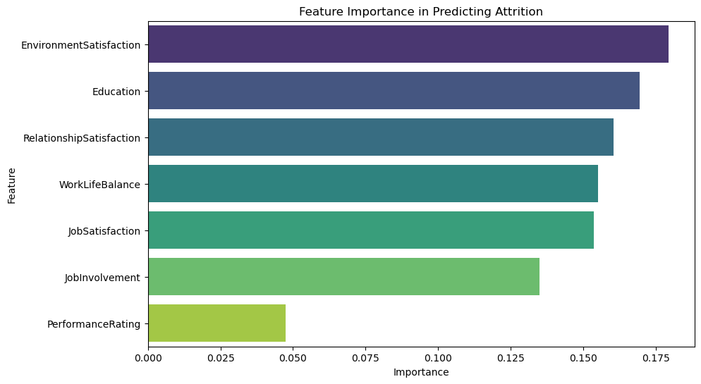

```
Feature Importance:
                    Feature  Importance
1   EnvironmentSatisfaction    0.179294
0                 Education    0.169275
5  RelationshipSatisfaction    0.160518
6           WorkLifeBalance    0.155025
3           JobSatisfaction    0.153560
2            JobInvolvement    0.134961
4         PerformanceRating    0.047367
```

```python
from sklearn.ensemble import RandomForestClassifier
import matplotlib.pyplot as plt


# Select relevant features (attributes) for prediction
features = ['Education', 'EnvironmentSatisfaction', 'JobInvolvement',
            'JobSatisfaction', 'PerformanceRating',
            'RelationshipSatisfaction', 'WorkLifeBalance']

# Extract features and target variable
X = df[features]
y = df['Attrition']

# Perform one-hot encoding for categorical variables
X = pd.get_dummies(X, drop_first=True)

# Split the data into training and testing sets
X_train, X_test, y_train, y_test = train_test_split(X, y, test_size=0.2, random_state=42)

# Initialize and train a random forest classifier
rf_model = RandomForestClassifier(random_state=42)
rf_model.fit(X_train, y_train)

# Get feature importances
feature_importances = rf_model.feature_importances_

# Create a DataFrame for better visualization
feature_importance_df = pd.DataFrame({'Feature': X.columns, 'Importance': feature_importances})

# Sort features by importance in descending order
feature_importance_df = feature_importance_df.sort_values(by='Importance', ascending=False)

# Plot the feature importance
plt.figure(figsize=(10, 6))
sns.barplot(x='Importance', y='Feature', data=feature_importance_df, palette='viridis')
plt.title('Feature Importance in Predicting Attrition')
plt.show()

# Display the feature importance DataFrame
print("\nFeature Importance:")
print(feature_importance_df)
```

##### Key Conclusions:

Lower environment satisfaction is associated with higher attrition rates. Suggestion: Assess and address factors affecting the work environment. Improve communication, collaboration, and work conditions to enhance overall satisfaction and reduce attrition. Job Satisfaction and Job Involvement:

Lower job satisfaction and job involvement correlate with higher attrition. Suggestion: Focus on improving job satisfaction through recognition programs, career development opportunities, and involving employees in decision-making processes. Work-Life Balance:

Employee Support Programs:

Conduct regular surveys to gather feedback on the work environment and implement improvements based on employee suggestions. Recognition and Career Development:

Implement recognition programs to acknowledge employee contributions. Provide clear pathways for career development and advancement. Flexible Work Arrangements:

Introduce flexible work arrangements to accommodate diverse employee needs and promote a healthy work-life balance. Continuous Monitoring:

Continuously monitor employee satisfaction through regular surveys and feedback sessions. Stay attuned to organizational changes and adapt strategies accordingly. Training for Managers:

Provide training for managers on effective communication, leadership, and employee engagement to foster a positive work environment. Employee Assistance Programs (EAPs):

Offer Employee Assistance Programs to provide mental health and well-being support. Data-Driven Decision-Making:

Use data analytics to regularly assess attrition patterns and identify emerging trends. Make informed decisions based on a combination of data insights and qualitative employee feedback. By implementing these suggestions, the organization can create a more supportive and engaging work environment, ultimately reducing attrition rates and fostering long-term employee satisfaction and retention. Regularly revisiting and adapting these strategies will ensure ongoing success in maintaining a positive workplace culture.